# Chapter 7: Linear Regression with `scikit-learn`

**Goals**

- Understand the basic concept of UV/vis spectroscopy and calibration
- Learn the basics of the `scikit-learn` package and required data structure
- Train a linear regression model (supervised learning)
- Predict the concentration based on unlabeled UV/vis spectra

## 7.1 Recap: Single Wavelength Linear Regression

In Chapter 6, we imported concentration data $c$ for a total of $o=8$ samples. But our ***"TuRbMaSteR 8000"*** was only able to measure at a single wavelength $\lambda_{j=276} = \lambda_{276} = 276$ nm. This is sufficient for the basic task of predicting the concentration of a single component based on single-wavelength-measurements. If we want to expand the capabilities of our models, e.g. predict concentrations in multi-component systems or say which coffee brand is being analyzed, we need to change our measurement device because we need **additional information**.

[figure not shown]

**Figure 7.1:** *The trusted* **"TuRbMaSteR 8000"*** and linear regression analysis from chapter 6.*

## 7.2 UV/vis Spectral Data and the Resulting Data Structure

### 7.2.1 Basic Working Principle

To enhance our methods for future applications, we perform **multi-wavelength** measurements (here *UV/vis spectrometry*) to analyze our samples. Therefore, we introduce our brand new measurement device called ***Spektralknecht***. Light interacts with molecules and bulk materials in various ways. We understood and used this already for our single wavelength measurements. The balance of different interactions is highly dependent on the wavelength of the photon. By measuring multiple wavelengths in the UV and visible range (UV/vis), we get something like a "fingerprint" of the sample.

[figure not shown]

**Figure 7.2:** *Theory of UV/vis spectrometry (left) and the new* **"Spektralknecht"*** (right).*

### 7.2.2 Calibration and Data Structure

Again, we do not know the relationship between this fingerprint and our desired information (e.g. caffeine concentration). Therefore, we have to perform a **calibration**, i.e. train a regression model on labeled data. The basic principle stays the same but now, each of our $o$ samples corresponds to one *spectrum*, i.e. an array of $J$ absorbance values measured at wavelengths $\lambda_{j}$ (instead of a single value). See the figure below to understand how our data is structured.

[figure not shown]

**Figure 7.3:** *Principle of UV/vis calibration procedure and data structure of calibration data.*

In the last two lectures, we learned that performing a calibration essentially means optimizing some model parameters (like the slope and offset of a straight line). We did most of this *by hand*, but have already seen that it is useful to fall back on community-driven, large scale projects. Today we use the [`scikit-learn`](https://scikit-learn.org/stable/) package, which offers a great deal of regression models we can train and use.

> ***The Goal:*** Build a regression model based on a given *training dataset* (calibration data). Then, use this model to predict the concentration of a *new/unseen* absorbance spectrum.

### 7.2.3 Data Structure in Mathematical, `scikit-learn` Language

The scikit-learn library works with the following data structure and nomenclature:

1. The **target array** (here: concentration data) is a numpy-array of shape $(O\times P)$. See the $c$-array in Figure 7.3.
   - $O$ is the number of **samples**
   - $P$ is the number of **outputs** (here: a single (1) caffeine concentration $\rightarrow P=1$).
2. Each line in the concentration array corresponds to one *spectrum* measured by "Spektralknecht". The shape of this so-called **samples matrix** is $(O\times J)$. See the $A$ array in Figure 7.3.
   - $O$ is the number of **samples**
   - $J$ is the number of **features** (here: number of wavelengths $\lambda$)
3. When we want to apply or test the calibration model, we want to **predict** the concentration based on an unlabeled spectrum. Each *new/unknown* spectrum needs to be an array of shape $(1\times J)$. You can predict a whole set of *new/unknown* data by passing an array of shape $(O\times J)$ with $O$ again being the number of samples to predict.

> Depending on the amount of outputs $P$ (dependent variables) and features $J$ (independent variables), the following definitions result:
> - **Simple** linear regression: One output ($P=1$) and one feature ($J=1$)
> - **Multiple** linear regression: One output ($P=1$) and multiple features ($J>1$)
> - **Multivariate** linear regression: Multiple outputs ($P>1$) and multiple features ($J>1$)

> Note, that these definitions are not always 100% precise, but we will settle on this. See [1](https://stats.stackexchange.com/questions/2358/explain-the-difference-between-multiple-regression-and-multivariate-regression) or [2](https://www.mathworks.com/help/stats/linear-regression.html) for some further reading.

### 7.2.4 Data Import

Before performing any regression analysis, we have to import the respective data. Luckily, you already worked on this during the homework of chapter 5, right? Right?

The `./data/uv_vis_calibration_data` folder contain UV/vis raw data as `.txt` files with the following naming convention:

`date_name_concentration_repetition number.txt`

In the homework of chapter 5, you programmed the function `read_calib_folder(folder)` that takes an absolute path as input. It returns the following numpy-arrays, which miraculously already fit the specific structure demanded by the `scikit-learn` package (see 7.2.3 above). We will not go into detail on this function here, but simply import it from `./mod/import_functions.py`.

- `wl`: Wavelength ($\lambda$) data. This is identical in each text file. `shape = (301,)`
- `c`: Concentration data for each file inside `folder`, extracted from the file name. `shape = (F,)`, where `F` is the number of files inside `folder`.
- `A`: Absorbance data for each wavelength and each concentration. `shape = (F,301)`

```python
from mod.import_functions import read_calib_folder

# This is the main body of our python file again. Let's call our function and see the output.
wl, A_train, c_train = read_calib_folder('./data/uv_vis_calibration_data/')

print('The wavelength array has shape', wl.shape)
print('The absorbance array has shape', A_train.shape)
print('The concentration array has shape', c_train.shape)
```

```
The wavelength array has shape (301,)
The absorbance array has shape (8, 301)
The concentration array has shape (8,)
```

The `./data/exp_data` folder contains multiple subfolders, where each of them represents a single experiment. Inside an experimental folder (like e.g. `./data/exp_data/230630_exp_1`), you'll find UV/vis raw data as `.txt` files with the following naming convention:

In the homework of chapter 5, you programmed the function `read_exp_folder(folder, rep=1)` that takes an absolute path and a repetition number as input. It returns the following numpy-arrays, which miraculously already fit the specific structure demanded by the `scikit-learn` package (see 7.2.3 above). We will not go into detail on this function here, but simply import it from `./mod/import_functions.py`.

- `wl`: Wavelength ($\lambda$) data. This is identical in each text file. `shape = (301,)`
- `t`: Time data for each file inside `folder`, extracted from the file name. `shape = (T,)`, where `T` is the number of unique times inside `folder`. All repetitions are stored at the same discrete time steps.
- `A`: Absorbance data for each wavelength and each point in time. `shape = (T,301)`

```python
from mod.import_functions import read_exp_folder
import numpy as np

# Extract experimental data of measurement 1 (for every repetition)
wl, A_exp1_rep1, t_exp = read_exp_folder('./data/exp_data/230630_exp_1/', rep=1)
_, A_exp1_rep2, _ = read_exp_folder('./data/exp_data/230630_exp_1/', rep=2)
_, A_exp1_rep3, _ = read_exp_folder('./data/exp_data/230630_exp_1/', rep=3)

# Maybe we want to only look at the mean absorbance values?
A_exp1_mean = np.mean([A_exp1_rep1, A_exp1_rep2, A_exp1_rep3], axis=0)
print('The wavelength array has shape', wl.shape)
print('The (mean) absorbance array has shape', A_exp1_mean.shape)
print('The time array has shape', t_exp.shape)
```

```
The wavelength array has shape (301,)
The (mean) absorbance array has shape (9, 301)
The time array has shape (9,)
```

## 7.3 Multiple Linear Regression with `scikit-learn`

We now have access to our *training data* `(A_train, c_train)` and our *experimental data* `A_exp1_mean` for which we want to *predict* the unknown caffein concentrations based on UV/vis spectra.

### 7.3.1 Basic Theory and Model Training

Chapter 6 showed us, how we can use optimization techniques to minimize a certain error between our training samples and a linear model. In case of multiple or multivariate linear regression, the same core principle applies, although we now have multiple independent variables (features) and multiple dependent variables (outputs). Let's see the example for a single output value (here, the caffeine concentration) and a single sample:

$$c = A_{1}w_{1} + A_{2}w_{2} + ... + A_{J}w_{J}$$

The concentration of this sample is calculated by the sum of all absorbance values multiplied by a coefficient. As a reference, remember how we calculated the concentration in chapter 6 by multiplying the absorbance value with the *slope* coefficient ($w_1$) to obtain the concentration. In general, i.e. extending this equation to $P$ outputs and $O$ samples, we can write

$$\mathbf{c_{\mathrm{pred}}} = \mathbf{A}\cdot\mathbf{w}.$$

$\mathbf{w}\in\mathbb{R}^{J\times P}$ (`shape=(n_features, n_outputs)`) is the coefficient array and $\mathbf{A}\in\mathbb{R}^{O\times J}$ (`shape=(n_samples, n_features)`) contains our UV/vis data, i.e. wavelength-specific absorbance values. Performing the matrix multiplication as shown above yields the concentration array $\mathbf{c_{\mathrm{pred}}}\in\mathbb{R}^{O\times P}$ (`shape=(n_samples, n_outputs)`), which contains the *predictions* of our model.

However, there is a minor problem: The values of the coefficient array $\mathbf{w}$ are currently *unknown* and need to be estimated. Finding these coefficients is therefore called *training* the model as it allows subsequent predictions with the equation above. In order to find $\mathbf{w}$, we follow the same procedure as in our simple regression model from chapter 6. We use our calibration (training) data ($\mathbf{c_{\mathrm{exp}}},\mathbf{A})$ and optimize $\mathbf{w}$ until the predicted concentrations match the experimental ones best. In mathematical terms, we can re-phrase the training of the model as an optimization problem:

$$\min_{\mathbf{w}} (\mathbf{A}\cdot\mathbf{w} - \mathbf{c_{\mathrm{exp}}})^2 = \min_{\mathbf{w}} (\mathbf{c_{\mathrm{pred}}} - \mathbf{c_{\mathrm{exp}}})^2$$

### 7.3.2 A Note on the y-Intercept

The equation above does not contain the *offset* ($w_0$) from chapter 6, however, we can easily add this back in:

$$c = w_0 + A_{1}w_{1} + A_{2}w_{2} + ... + A_{J}w_{J}$$

In this case, $\mathbf{w}$ has `shape=(n_features+1, n_outputs)` and $\mathbf{A}$ has `shape=(n_samples, n_features+1)`, where the first column of $\mathbf{A}$ is full of $1$. Take a pen and paper and try to remember how matrix multiplications work. We will see in a second that `scikit-learn` offers some easy functionality to perform these modifications to our raw data.

### 7.3.3 Implementation in Python with `sklearn.linear_model.LinearRegression( )`

Luckily, we simply need to keep this theoretical background in mind in order to explain what our python code really does. The application is far more practical and simple as all of the mathematics are done magically *"under the hood"* when using the `scikit-learn` package. An overview of all available regression models can be found online in the `scikit-learn` [documentation](https://scikit-learn.org/stable/). The regression model we use is called [**O**rdinary **L**east **S**quares (OLS)](https://scikit-learn.org/stable/modules/linear_model.html#ordinary-least-squares), while the explicit **model class** is called [`sklearn.linear_model.LinearRegression( )`](https://scikit-learn.org/stable/modules/generated/sklearn.linear_model.LinearRegression.html#sklearn.linear_model.LinearRegression).

We can create **instances** of the class `sklearn.linear_model.LinearRegression( )` and store them in a variable `ols_model`. Think of each instance as an individual model (or black box). Each *instance* of our linear regression has access to *methods* of the class. The most important parameters and methods include the following:

**Parameters:**

- `fit_intercept=True`: The `fit_intercept` argument includes the offset values in the model (see chapter 7.3.2) and is `True` by default.

**Methods:**

- `fit(X_train, y_train)`. This methods takes two inputs and both arrays are considered our *training data*. `X_train` contains feature data and has shape `(n_samples, n_features)`, while `y_train` contains the target values and has shape `(n_samples, n_outputs)`. In our example, `X_train` corresponds to $\mathbf{A}$ and `y_train` corresponds to $\mathbf{c_{\mathrm{exp}}}$. Calling the `.fit` method optimizes the internal parameters / coefficients $\mathbf{w}$ of the `ols_model`.
- `predict(X)`. This method takes a single input `X` with shape `(n_samples, n_features)` and returns the predicted values `y_pred` for each sample.
- `score(X_test, y_test)`. This methods takes two inputs, both of which are considered *test data*. `X_test` contains feature data and has shape `(n_samples, n_features)`. `y_test` contains the corresponding true values for `X_test` and has shape `(n_samples, n_targets)`. The method first predicts `y_pred = ols_model.predict(X_test)` and then compares `y_pred` with `y_test`. It returns the coefficient of determination $R^2$ of our trained model.

> ***Note***: It is really nice that all of the math of chapter 6 and 7.3.1 is hidden behind the single command `.fit( )`. Maybe this makes you think* "well, why should I care at all about the theory then?"*. Valid point. However, not knowing what you are doing and simply applying some models or running some scripts is a recipe for disaster. You wouldn't be able to detect whether or not your predictions actually make any sense and if not, why they don't. Additionally, you don't know how to pre-process your data. To be clear: You don't necessarily need to understand every last detail of the algorithms, but whenever you use a model, you should at least understand the basic concepts behind it!

Well, that war a lot of text and a lot of information. In the code example below you'll see that performing a linear regression with `scikit-learn` is actually really simple. We'll follow these steps:

1. Read in our training (calibration) data:
   1. Absorbance data: `A_train` with shape $(O\times J)$
   2. Associated caffein concentrations `c_train` with shape $(O\times 1)$
2. Create a regression model **instance** called `ols_model`.
3. Apply the `ols_model.fit(A_train, c_train)` method to optimize $\mathbf{w}$, i.e. fit or train the model to our data.
4. Apply the `ols_model.score(A_train, c_train)` method to see how well the linear model represents the data.
5. Save the model in a `.npy` file so that we don't have to train the model every time.
6. Read in out experimental data `A_exp` with shape $(T\times J)$.
7. Use the `ols_model.predict(A_exp)` method to calculate $\mathbf{c}$ for our experimental, time-dependent absorbance values. Save the predictions in `c_pred`. It is very simple to predict multiple experimental samples (here: discrete time steps) at once. For each line in `A_exp[i,:]`, a associated prediction for `c_pred[i,]` is calculated individually, corresponding to `t[i]`.
8. Visualize all the data!

```
The trained model has a coefficient of determination (R2) of 1.0
The coefficients of the OLS model have the shape (301,)
For reference, we have 301 features and one output (c).
```

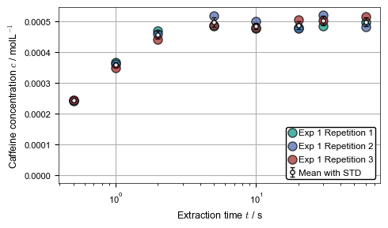

```python
from sklearn.linear_model import LinearRegression
import matplotlib.pyplot as plt
import mod.my_plotter as mp
mp.init_plot(scl_a4=1, page_lnewdth_cm=10, mrksze=8)

# Create an instance variable for our OLS model
# The fit_intercept option defines whether or not the offset parameter should be fit (or set to 0)
ols_model = LinearRegression(fit_intercept=True)

# Import the training data (already done in the cell above)
wl, A_train, c_train = read_calib_folder('./data/uv_vis_calibration_data/')

# Fit the linear model to our training data
ols_model.fit(A_train, c_train)

# Check and print how good our model is
R2 = ols_model.score(A_train, c_train)
print('The trained model has a coefficient of determination (R2) of', R2)

# Print the shape of our coefficient matrix
print('The coefficients of the OLS model have the shape', ols_model.coef_.shape)
print(f'For reference, we have {len(wl)} features and one output (c).')

# Save our trained model in a .npy file
np.save('data/my_ols_model.npy',ols_model)

# Import the experimental data and calculate mean (already done in the cell above)
wl, A_exp1_rep1, t_exp = read_exp_folder('./data/exp_data/230630_exp_1/', rep=1)
_, A_exp1_rep2, _ = read_exp_folder('./data/exp_data/230630_exp_1/', rep=2)
_, A_exp1_rep3, _ = read_exp_folder('./data/exp_data/230630_exp_1/', rep=3)

# Use the fitted model to predict unknown concentration values
c_pred_exp_1_rep1 = ols_model.predict(A_exp1_rep1)
c_pred_exp_1_rep2 = ols_model.predict(A_exp1_rep2)
c_pred_exp_1_rep3 = ols_model.predict(A_exp1_rep3)
c_pred_exp_1_mean = np.mean((c_pred_exp_1_rep1, c_pred_exp_1_rep2, c_pred_exp_1_rep3), axis=0)
c_pred_exp_1_std = np.std((c_pred_exp_1_rep1, c_pred_exp_1_rep2, c_pred_exp_1_rep3), axis=0)

# Plot the data
fig, ax = plt.subplots(figsize=(5,3))

# Single measurements
ax.scatter(t_exp, c_pred_exp_1_rep1, label='Exp 1 Repetition 1', edgecolors='k', color=mp.green, alpha=0.7)
ax.scatter(t_exp, c_pred_exp_1_rep2, label='Exp 1 Repetition 2', edgecolors='k', color=mp.blue, alpha=0.7)
ax.scatter(t_exp, c_pred_exp_1_rep3, label='Exp 1 Repetition 3', edgecolors='k', color=mp.red, alpha=0.7)
# Mean and standard deviation
ax.errorbar(t_exp, c_pred_exp_1_mean, yerr=c_pred_exp_1_std, color='k', lw=0, marker='o', mfc='w',
            mec='k', ms=4, mew=1, capsize=2, elinewidth=1, alpha=0.9, label=r'Mean with STD')

ax.set_xlabel('Extraction time $t$ / s')
ax.set_ylabel('Caffeine concentration $c$ / molL$^{-1}$')
ax.set_xscale('log')
ax.grid(True)
ax.legend(loc='lower right', fontsize='small', framealpha=1, ncol=1, labelspacing = 0.6)
plt.tight_layout()
```

## 7.4 Final Notes

Think about this for a second. In a couple lines of code we managed to...

- ... **automate** the **import** of entire UV-VIS **raw-data** folders. You can apply this to any problem.
- ... **fit** a regression model on our calibration data. This took 1 (one) line of code. You can apply this to any problem.
- ... **predict** arbitrary many experimental measurements. You can apply this to any problem.

The workflow you just learned can be applied in so many scenarios in your academic but also industrial career. Think about how you would have done this *"manually"*, i.e. in your favorite spreadsheet software. I bet it would require more effort!